# random

```python
import numpy as np
import matplotlib.pyplot as plt
import math
import random
pi = np.pi
plt.rcParams["font.family"] = "serif"
plt.rcParams['mathtext.fontset'] = 'cm'
```

### Uniform Distribution $U(0,1)$

The probability density function (pdf) is $$f(x)=\begin{cases} 1, & 0<x<1,\\ 0, & \text{otherwise}. \end{cases}$$ The cumulative distribution function (cdf) is $$F(x)=\begin{cases} 0, & x<0,\\ x, & 0\leq x<1,\\ 1, & x \geq 1. \end{cases}$$

```python
u = random.random()
print(u) #print 1 random number
u = np.random.rand(10)
print(u) #print 10 random numbers
```

```
0.995471892113296
[0.71427655 0.14826004 0.62818569 0.90525333 0.47628864 0.27233002
 0.49322046 0.97913469 0.14817831 0.91054255]
```

### Bernoulli and Binomial Distributions

The probability mass function (pmf) of the Bernoulli distribution with a success probability $p\in[0,1]$ is \begin{equation} \pi_k = \begin{cases} 1-p, & k=0,\\ p, & k=1. \end{cases} \end{equation} This distribution can be obtained by \begin{equation} X = \chi_{(1-p,1]}(U) \end{equation} where $U\sim U(0,1)$ and $\chi_{(1-p,1]}:[0,1]\to\mathbb{R}$ is the characteristic function of the interval $(1-p,1]$ defined by \begin{equation} \chi_{(1-p,1]}(u) = \begin{cases} 0, & 0\leq u \leq 1-p,\\ 1, & 1-p < u \leq 1. \end{cases} \end{equation}

The pmf of the Binomial distribution with $n$ trials and a success probability $p\in[0,1]$ is \begin{equation} \pi_k = \binom{n}{k}p^k(1-p)^{n-k},\quad k=0,1,\ldots,n. \end{equation} Given $n$ i.i.d. Bernoulli random variables $X_1, X_2, \ldots, X_n$ with parameter $p$, the random variable \begin{equation} Y = X_1 + X_2 + \cdots + X_n. \end{equation} follows the binomial distribution with parameters $n$ and $p$.

```python
from scipy.special import comb

def Bernoulli(p=0.5):
    u = random.random()
    return np.where(u<=(1-p),0,1)
print(Bernoulli())

def P_Bin(k,n=10,p=0.5):
    return comb(n, k) * p**k * (1-p)**(n-k)

def Binomial(n=10,p=0.5):
    u = np.random.rand(n)
    return np.where(u<=(1-p),0,1).sum()
print(Binomial())
```

```
1
3
```

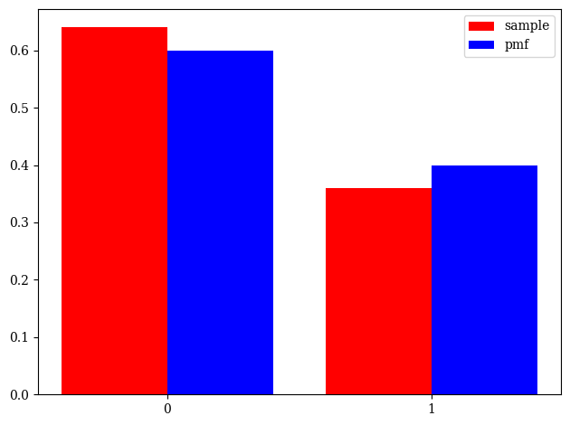

```python
p = 0.4

x = np.array([Bernoulli(p) for i in range(500)])
xtheo = np.array([0,1])
pii = np.array([1-p,p])

counts, bins = np.histogram(x,bins=np.array([0,1,2]), density=True)

width = 0.4  # the width of the bars
multiplier = -1
offset = width * multiplier/2
rects = plt.bar(xtheo+offset, counts, width, color='red', label='sample')
# plt.bar_label(rects, padding=3)

multiplier = 1
offset = width * multiplier/2
rects = plt.bar(xtheo+offset, pii, width, color='blue', label='pmf')
# plt.bar_label(rects, padding=3)

plt.xticks(xtheo, xtheo)
plt.legend()

plt.tight_layout()
plt.savefig("Bernoulli.pdf")
```

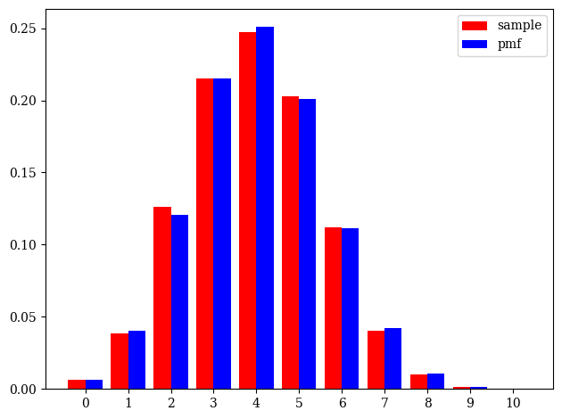

```python
p = 0.4
n = 10

x = np.array([Binomial(n,p) for i in range(10000)])
xtheo = np.arange(0,n + 1)
pii = np.array([P_Bin(i,n,p) for i in range(n+1)])

xbin  = np.arange(0,n + 2)
counts, bins = np.histogram(x,bins=xbin, density=True)

width = 0.4  # the width of the bars
multiplier = -1
offset = width * multiplier/2
rects = plt.bar(xtheo+offset, counts, width, color='red', label='sample')
# plt.bar_label(rects, padding=3)

multiplier = 1
offset = width * multiplier/2
rects = plt.bar(xtheo+offset, pii, width, color='blue', label='pmf')
# plt.bar_label(rects, padding=3)

plt.xticks(xtheo, xtheo)
plt.legend()

plt.tight_layout()
plt.savefig("Binomial.pdf")
```

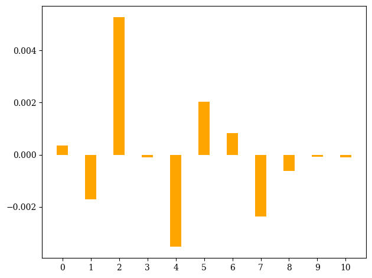

```python
diff = counts - pii
rects = plt.bar(xtheo, diff, width, color='orange')
# plt.bar_label(rects, padding=3)

plt.xticks(xtheo, xtheo)

plt.tight_layout()
plt.savefig("Binomial_diff.pdf")
```

### Geometric Distribution

The pmf with $p\in(0,1]$ is $$p_X(k) = p(1-p)^{k-1},\quad k=1,2,\ldots.$$ The cdf is $$F(x) = 1-(1-p)^{\lfloor x \rfloor}.$$ Consider $U\sim U(0,1)$. The random variable following the geometric distribution can be obtained by $X=g(U)$ where \begin{equation} g(u) = \left\lceil \frac{\ln(1-u)}{\ln(1-p)} \right\rceil. \end{equation}

```python
def P(k, p = 0.5):
    return p*(1-p)**(k-1)

def Geo(p = 0.5):
    u = random.random()
    return int(np.ceil( (np.log(1-u))/(np.log(1-p)) ))
print(Geo())
```

```
3
```

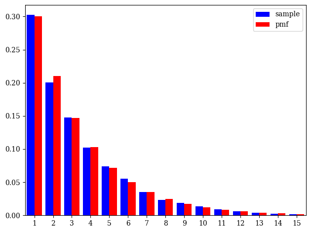

```python
p = 0.3

x = np.array([Geo(p) for i in range(10000)])
xmax = x.max()
xtheo = np.arange(1,xmax + 1)
pii = np.array([P(i,p) for i in range(1,int(xmax) + 1)])

xbin  = np.arange(1,xmax + 2)
counts, bins = np.histogram(x,bins=xbin, density=True)

width = 0.4  # the width of the bars
multiplier = -1
offset = width * multiplier/2
rects = plt.bar(xtheo+offset, counts, width, color='blue', label='sample')
# plt.bar_label(rects, padding=3)

multiplier = 1
offset = width * multiplier/2
rects = plt.bar(xtheo+offset, pii, width, color='red', label='pmf')
# plt.bar_label(rects, padding=3)

plt.xticks(xtheo, xtheo)
plt.legend()
plt.xlim([0.5,15.5])
plt.tight_layout()
plt.savefig("Geometric.pdf")
```

### Exponential Distribution $\mathrm{Exp}(\lambda)$

The pdf with $\lambda > 0$ is $$f(x) = \lambda e^{-\lambda x},\quad x\geq 0$$ The cdf is $$F(x)=\begin{cases} 0, & x<0,\\ 1-e^{-\lambda x}, & x\geq 0. \end{cases}$$ The inverse function is $$F^{-1}(y)=-\frac{1}{\lambda}\ln(1-y).$$ Consider $U\sim U(0,1)$. The random variable following $\mathrm{Exp}(\lambda)$ can be obtained by $X=F^{-1}(U)$.

```python
def f(x, lamb = 1):
    return lamb * np.exp(-lamb*x)

def Finv(x, lamb = 1):
    return -np.log(1-x)/lamb

def EXP(lamb = 1):
    u = random.random()
    return Finv(u, lamb)

print(EXP())
```

```
0.18669441698288947
```

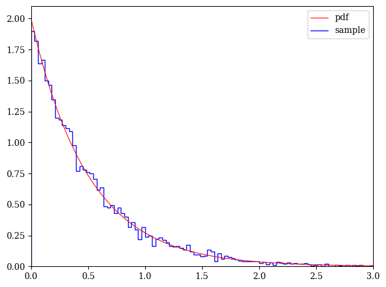

```python
lamb = 2

x = np.array([EXP(lamb) for i in range(10000)])
xmin = 0
xmax = 3
xbin = np.linspace(xmin, xmax, 100)
xtheo = np.linspace(xmin, xmax, 1000)
ftheo = f(xtheo,lamb)
counts, bins = np.histogram(x, bins = xbin, density=True)
plt.plot(xtheo,ftheo, color="red", linewidth = 0.8, label = "pdf")
plt.stairs(counts, bins, color="blue", label = "sample")
plt.xlim([xmin,xmax])
plt.legend()
plt.tight_layout()
plt.savefig("Exponential.pdf")
```

### Cauchy Distribution

The pdf is $$f(x)=\frac{1}{\pi}\frac{\gamma}{(x-x_0)^2+\gamma^2},\qquad\gamma>0,~x_0\in\mathbb{R}.$$ The cdf is $$F(x)=\int_{-\infty}^x f(t)\mathrm{d}t=\frac{1}{2}+\frac{1}{\pi}\arctan\left(\frac{x-x_0}{\gamma}\right).$$ The inverse function is $$F^{-1}(y)=x_0+\gamma\tan\left[\left(y-\frac{1}{2}\right)\pi\right].$$ Consider $U\sim U(0,1)$. The random variable following the Cauchy distribution can be obtained by $X=F^{-1}(U)$.

```python
def f(x, x0 = 0.0, gamma = 1.0):
    return gamma/(pi * ((x-x0)**2 + gamma**2))

def Finv(x, x0 = 0.0, gamma = 1.0):
    return x0 + gamma*np.tan((x-0.5)*pi)

def Cauchy(x0 = 0.0, gamma = 1.0):
    u = random.random()
    return Finv(u, x0, gamma)

print(Cauchy())
```

```
3.732467337862048
```

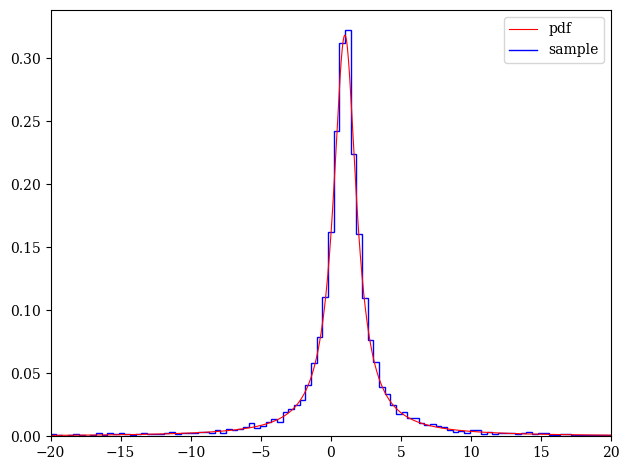

```python
x0 = 1.0
gamma = 1.0

x = np.array([Cauchy(x0,gamma) for i in range(10000)])
xmin = -20
xmax = 20
xbin = np.linspace(xmin, xmax, 100)
xtheo = np.linspace(xmin, xmax, 1000)
ftheo = f(xtheo,x0,gamma)
counts, bins = np.histogram(x, bins = xbin, density=True)
plt.plot(xtheo,ftheo, color="red", linewidth = 0.8, label = "pdf")
plt.stairs(counts, bins, color="blue", label = "sample")
plt.xlim([xmin,xmax])
plt.legend()
plt.tight_layout()
plt.savefig("Cauchy.pdf")
```

### Gamma Distribution $\Gamma(\alpha, \beta)$

The pdf with parameters $\alpha>0$ and $\beta>0$ is given by \begin{equation} f(x) = \frac{\beta^\alpha}{\Gamma(\alpha)} x^{\alpha-1} e^{-\beta x},\quad x\geq 0, \end{equation} where $\Gamma(\alpha)$ is the Gamma function defined by $$\Gamma(\alpha) = \int_0^\infty t^{\alpha-1} e^{-t}\mathrm{d}{t}.$$ Consider a random variable $Y\sim\mathrm{Exp}(\lambda)$ where \begin{equation} \lambda = \frac{\beta}{\alpha}. \end{equation} Suppose that $Y$ is independent of $U\sim U(0,1)$. Define a number \begin{equation} a = \frac{\alpha^\alpha}{\Gamma(\alpha)}e^{1-\alpha}, \end{equation} and an event \begin{equation} E=\{a U \lambda e^{-\lambda Y}\leq f(Y)\}. \end{equation} Then, we have \begin{align} \mathbb{P}(Y\leq x\mid E) = \frac{\Pr\big(\{Y\leq x\}\cap E\big)}{\Pr(E)} = \int_{-\infty}^x f(t)\mathrm{d}t. \end{align} Note that the probability of $E$ is \begin{align} \mathbb{P}(E) = \frac{1}{a}. \end{align}

```python
import scipy
def fgamma(x, alpha = 2, beta = 1):
    return ((beta**alpha) * (x**(alpha-1)) * np.exp(-beta * x))/scipy.special.gamma(alpha)

def Gamma(alpha = 2, beta = 1):
    a = ((alpha ** alpha)/scipy.special.gamma(alpha)) * np.exp(1-alpha)
    y = 0
    u = 1
    while (a * u * (beta/alpha) * np.exp(-(beta/alpha)*y) > fgamma(y,alpha,beta)):
        y = - np.log(1-random.random()) / (beta/alpha)
        u = random.random()
    return y
print(Gamma(alpha = 3,beta = 0.2))
```

```
13.531116372004874
```

```
Success rate is  0.6795704571147613
```

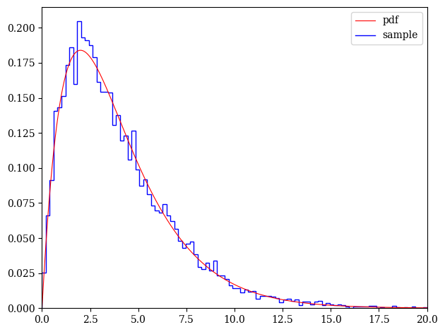

```python
alpha = 2
beta = 0.5

a = ((alpha ** alpha)/scipy.special.gamma(alpha)) * np.exp(1-alpha)
print("Success rate is ",1/a)

x = np.array([Gamma(alpha,beta) for i in range(10000)])
xmin = 0
xmax = 20
xbin = np.linspace(xmin, xmax, 100)
xtheo = np.linspace(xmin, xmax, 1000)
ftheo = fgamma(xtheo,alpha,beta)
counts, bins = np.histogram(x, bins = xbin, density=True)
plt.plot(xtheo,ftheo, color="red", linewidth = 0.8, label = "pdf")
plt.stairs(counts, bins, color="blue", label = "sample")
plt.xlim([xmin,xmax])
plt.legend()
plt.tight_layout()
plt.savefig("Gamma.pdf")
```

### Normal Distribution $N(\mu,\sigma^2)$

The pdf with parameters $\mu\in\mathbb{R}$ and $\sigma>0$ is given by \begin{equation} f(x) = \frac{1}{\sqrt{2\pi\sigma^2}}e^{-(x-\mu)^2/2\sigma^2}. \end{equation} The Box-Muller method can be employed to generate this distribution: for $U_1,U_2\sim U(0,1)$, if we define \begin{equation} R = \sqrt{-2\ln(U_1)},\qquad V = 2\pi U_2, \end{equation} \begin{equation} Z = R\cos(V),\qquad X = \mu + \sigma Z, \end{equation} then $X\sim N(\mu,\sigma^2)$.

```python
def fnormal(x, mu = 0, sigma=1):
    return (1/np.sqrt(2*pi*sigma**2)) * np.exp(-(x-mu)**2/(2*sigma**2))

def Normal(mu = 0, sigma=1):
    u1 = random.random()
    u2 = random.random()
    r = np.sqrt(-2*np.log(u1))
    v = 2*pi*u2
    z = r*np.cos(v)
    return mu + sigma * z
print(Normal())
```

```
-0.19552999942118598
```

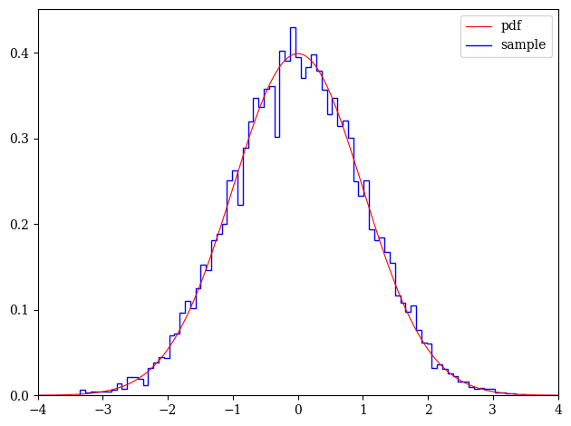

```python
mu = 0
sigma = 1

x = np.array([Normal(mu, sigma) for i in range(10000)])
xmin = -4
xmax = 4
xbin = np.linspace(xmin, xmax, 100)
xtheo = np.linspace(xmin, xmax, 1000)
ftheo = fnormal(xtheo, mu, sigma)
counts, bins = np.histogram(x, bins = xbin, density=True)
plt.plot(xtheo,ftheo, color="red", linewidth = 0.8, label = "pdf")
plt.stairs(counts, bins, color="blue", label = "sample")
plt.xlim([xmin,xmax])
plt.legend()
plt.tight_layout()
plt.savefig("Normal.pdf")
```

### Poisson Distribution

The pmf with $p\in(0,1]$ is $$\pi_k = e^{-\lambda}\frac{\lambda^k}{k!},\quad k=0,1,2,\ldots$$ Suppose that $X_1,X_2,\ldots$ are i.i.d. random variables with an exponential distribution $\mathrm{Exp}(\lambda)$. For a given integer $n\geq 1$, define the random variable $S_n$ by \begin{equation} S_n = \sum_{i=1}^n X_i. \end{equation} If we define a discrete random variable $N$ by \begin{equation} N(\omega) = \min\{n\geq 0\mid 1<S_{n+1}(\omega)\},\qquad \omega\in\Omega_P, \end{equation} then $N$ follows the Poisson distribution with parameter $\lambda$. This is Knuth's algorithm for generating Poisson distributions.

```python
import math
def P(k, lamb = 1):
    return np.exp(-lamb) * lamb**k /math.factorial(k)

def EXP(lamb = 1):
    u = random.random()
    return -np.log(1-u)/lamb

def Poisson(lamb = 1):
    s = EXP(lamb)
    i = 0
    while (s<=1):
        s += EXP(lamb)
        i += 1
    return i
print(Poisson(lamb = 0.5))
```

```
1
```

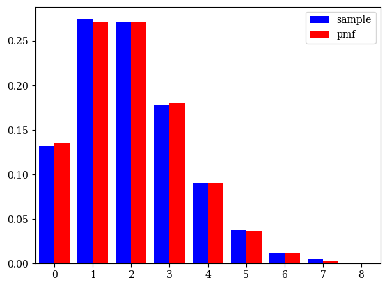

```python
lamb = 2

x = np.array([Poisson(lamb) for i in range(10000)])
xmax = x.max()
xtheo = np.arange(0,xmax + 1)
pii = np.array([P(i,lamb) for i in range(0,int(xmax)+1)])

xbin  = np.arange(0,xmax + 2)
counts, bins = np.histogram(x,bins=xbin, density=True)

width = 0.4  # the width of the bars
multiplier = -1
offset = width * multiplier/2
rects = plt.bar(xtheo+offset, counts, width, color='blue', label='sample')
# plt.bar_label(rects, padding=3)

multiplier = 1
offset = width * multiplier/2
rects = plt.bar(xtheo+offset, pii, width, color='red', label='pmf')
# plt.bar_label(rects, padding=3)

plt.xticks(xtheo, xtheo)
plt.legend()
plt.xlim([-0.5,8.5])
plt.savefig("Poisson.pdf")
```

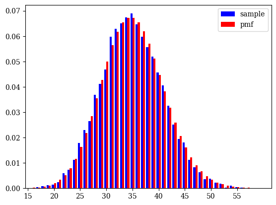

```python
lamb = 35

x = np.array([Poisson(lamb) for i in range(10000)])
xmax = x.max()
xtheo = np.arange(0,xmax + 1)
pii = np.array([P(i,lamb) for i in range(0,int(xmax)+1)])

xbin  = np.arange(0,xmax + 2)
counts, bins = np.histogram(x,bins=xbin, density=True)

width = 0.4  # the width of the bars
multiplier = -1
offset = width * multiplier/2
rects = plt.bar(xtheo+offset, counts, width, color='blue', label='sample')
# plt.bar_label(rects, padding=3)

multiplier = 1
offset = width * multiplier/2
rects = plt.bar(xtheo+offset, pii, width, color='red', label='pmf')
# plt.bar_label(rects, padding=3)

xtheo_filtered = xtheo[np.arange(0,xmax + 1,5)]
plt.xticks(xtheo_filtered, xtheo_filtered)
plt.legend()
plt.xlim([14.5,61.5])
plt.savefig("Poisson1.pdf")
```

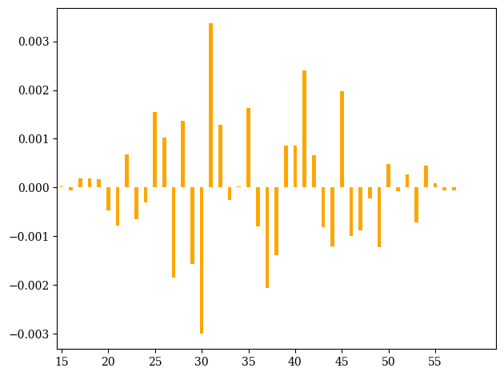

```python
diff = counts - pii
rects = plt.bar(xtheo, diff, width, color='orange')
# plt.bar_label(rects, padding=3)

plt.xticks(xtheo_filtered, xtheo_filtered)
plt.xlim([14.5,61.5])
plt.tight_layout()
plt.savefig("Poisson1_diff.pdf")
```